# PHYS 5640 - HW 01

## Steven Stetzler (sgs7cr)

We seek to find the themodynamic properties and behavior of a 1D quantum Ising ring using **Exact Diagonalization**. This 1D quantum Ising ring model is defined by its Hamiltonian given by $$ \hat{\mathcal{H}} = -J \sum_{i=1}^{N} \hat{\sigma}_i^z\hat{\sigma}_{i+1}^z + h \sum_{i = 1}^{N} \hat{\sigma}_i^x. $$ This model exists on a ring due to the imposition of periodic boundary conditions: $\sigma_{N + 1} = \sigma_{1}$, meaning the last spin is adjacent to the first spin. Here, we use the Pauli matrices $ \hat{\sigma}^z $ and $ \hat{\sigma}^x $, which are defined as $ \hat{\sigma}^z = \begin{pmatrix} 1 & 0 \\ 0 & -1 \end{pmatrix} $ and $ \hat{\sigma}^x = \begin{pmatrix} 0 & 1 \\ 1 & 0 \end{pmatrix} $. In our Hamiltonian $ \hat{\mathcal{H}} $, the $\hat{\sigma}_i^z\hat{\sigma}_{i+1}^z$ terms represent the tendency for spins adjacent to one another to want to align with one another. The interaction coefficient $J$ represents the strength of that tendancy to align. The $ \hat{\sigma}_i^x $ terms represent the response of the spins to the presense of a transverse magnetic field with field strength $h$.

Solving this system exactly corresponds to finding the **eigenvalues**, $\epsilon_m$, and corresponding **eigenvectors** of the Hamiltonian $ \hat{\mathcal{H}} $ through **exact diagonalization**. These eigenvalues represent the energies of the states of the Ising ring in a diagonalized basis. In our implementation, eigenvalues and eigenvectors are found using the `numpy.linalg.eig()` function from the `numpy` Python package.

For $N$ spins, this Hamiltonian is of dimensions $2^N \times 2^N$, which makes exact diagonalization a computational challenge for even moderately sized $N$. In our implementation, solving the system exactly with just $N = 10$ takes a while to run, and we could not expect a timely solution for $ N \gtrsim 20 $.

Once our eigenvalues are found, we can compute the **partition function** $Z$, which can be used to find the thermodynamic properties of our system, through simple manipulations of the partition function. The partition function is given by $$ Z = \text{Tr(}e^{-\beta \hat{\mathcal{H}}}\text{)} = \sum_{m = 1}^{N} e^{-\beta \epsilon_m } $$ where $\beta = \frac{1}{k_B T}$ with $k_B$, the Boltzmann constant, set equal to 1. We can then find the energy per spin $E$ and the heat capacity $C = dE/dT$ of our Ising ring system using the relations $$ E = \frac{\langle \hat{\mathcal{H}} \rangle}{N} = \frac{-1}{N} \frac{\partial \text{ln}Z}{\partial \beta} $$ and $$ C = \frac{\langle \hat{\mathcal{H}}^2 \rangle - \langle \hat{\mathcal{H}} \rangle^2}{NT^2} = \frac{1}{T^2} \frac{\partial^2 \text{ln}Z}{\partial \beta^2} $$

Below, you will find a Python implementation for solving an Ising ring of sizes $N = 3, 4, 5,$ and $10$. For several interaction scales $ h / J $, we plot the average energy $E / J$ and the heat capacity $C / J$ as a function of the temperature scale $T / J$.

We import several useful Python packages to perform the computation. `numpy` provides numerical analysis tools, and our diagonalization routine through the `numpy.linalg.eig()` function. `matplotlib` provides plotting functions through the `pyplot` package. For any python installation, these can be installed using:

```
$ sudo python -m pip install numpy matplotlib
```

```python
import numpy as np
import matplotlib.pyplot as plt
%matplotlib inline
# Ignore math warnings
import warnings
warnings.filterwarnings('ignore')
import math
```

The following lines allow us to adjust our plots, made with `matplotlib`.

```python
from matplotlib import rcParams
rcParams.update({'xtick.major.pad': '7.0'})
rcParams.update({'xtick.major.size': '7.5'})
rcParams.update({'xtick.major.width': '1.5'})
rcParams.update({'xtick.minor.pad': '7.0'})
rcParams.update({'xtick.minor.size': '3.5'})
rcParams.update({'xtick.minor.width': '1.0'})
rcParams.update({'ytick.major.pad': '7.0'})
rcParams.update({'ytick.major.size': '7.5'})
rcParams.update({'ytick.major.width': '1.5'})
rcParams.update({'ytick.minor.pad': '7.0'})
rcParams.update({'ytick.minor.size': '3.5'})
rcParams.update({'ytick.minor.width': '1.0'})
rcParams.update({'font.size': 18})
rcParams.update({'font.sans-serif':'Arial'})
rcParams.update({'font.family':'sans-serif'})
```

### Computing the Hamiltonian

`get_sigma_matrices_x()` computes the $N$ Pauli matrices $\hat{\sigma}_i^x$ for $ i \in \left[1, N \right]$, which each apply the Pauli matrix $\hat{\sigma}^x$ to the $i^{th}$ spin. This is done by using tensor products (also known as Kronecker products) between the Pauli matrix $\hat{\sigma}^x$ and the $2 \times 2$ identity matrix $\hat{I}_2 = \begin{pmatrix} 1 & 0 \\ 0 & 1 \end{pmatrix}$. For example, we can construct $\hat{\sigma}_0^x$ as follows:

$$ \hat{\sigma}_0^x = \hat{\sigma}_x \otimes \hat{I}_2 \otimes \hat{I}_2 \otimes ... \otimes \hat{I}_2 $$

where we have $N - 1$ tensor products between $\hat{\sigma}_x$ and the identity $ \hat{I} $. We can use the fact that $ \hat{I}_2 \otimes \hat{I}_2 = \hat{I}_4 $, or more generally $ \hat{I}_n \otimes \hat{I}_n = \hat{I}_{n\times n} $ to simplify this to

$$ \hat{\sigma}_0^x = \hat{\sigma}_x \otimes \hat{I}_2 \otimes \hat{I}_2 \otimes ... \otimes \hat{I}_2 = \hat{\sigma}_x \otimes \hat{I}_{2^{N - 1}}. $$

Generalizing to any of the spins, specified by $i$, we find

$$ \hat{\sigma}_i^x = \hat{I}_{2^{i}} \otimes \hat{\sigma}_x \otimes \hat{I}_{2^{N - 1 - i}}, $$

reducing $N$ tensor products to at most 3, given we can construct an identity matrix of an arbitrary size. This is implemented below in the function `get_sigma_matrices_x()` and implemented similarly in the function `get_sigma_matrices_z()` except using the Pauli matrix $\hat{\sigma}^z$. Within these functions, the tensor product (or Kronecker product) $\otimes$ is implemented using the `numpy.kron()` function, and the construction of the identity matrices is implemented using the `numpy.eye()` function.

```python
def get_sigma_matrices_x(N):
    mats = []
    pauli_x = np.array([[0, 1], [1, 0]])

    for i in range(N):
        dim_left = 2 ** (i)
        dim_right = 2 ** (N - i - 1)

        identity_left = np.eye(dim_left)
        identity_right = np.eye(dim_right)

        mat = np.kron(identity_left, pauli_x)
        mat = np.kron(mat, identity_right)
        mats.append(mat)

    return mats
```

```python
def get_sigma_matrices_z(N):
    mats = []
    pauli_z = np.array([[1, 0], [0, -1]])

    for i in range(N):
        dim_left = 2 ** (i)
        dim_right = 2 ** (N - i - 1)

        identity_left = np.eye(dim_left)
        identity_right = np.eye(dim_right)

        mat = np.kron(identity_left, pauli_z)
        mat = np.kron(mat, identity_right)
        mats.append(mat)

    return mats
```

Given we have each of the Pauli matrices $\hat{\sigma}_i^x$ and $\hat{\sigma}_i^z$, we can find the individual sum components in the Hamiltonian: $$ \text{x_term} = \sum_{i=1}^{N} \hat{\sigma}_i^x $$

and

$$ \text{z_term} = \sum_{i=1}^{N} \hat{\sigma}_i^z \hat{\sigma}_{i + 1}^z $$

```python
def get_hamiltonian_terms(N):
    # Get Sigma X Matrices for each spin
    x_mats = get_sigma_matrices_x(N)
    # Sum up those matrices to get them x-term
    x_term = np.sum(x_mats, axis=0)
    # Get Sigma Z Matrices for each spin
    z_mats = get_sigma_matrices_z(N)
    # Impose periodic boundary conditions
    z_mats.append(z_mats[0])
    # mulitply adjacent matrices and sum them all up
    z_term = np.sum([np.dot(z_mats[i], z_mats[i + 1]) for i in range(len(z_mats) - 1)], axis=0)

    return z_term, x_term
```

Given the above, we can construct the Hamiltonian using the modified *interaction scale* $ H / J $ (implemented with variable name `h_J`) as $$ \frac{\hat{\mathcal{H}}}{J} = - \sum_{i=1}^{N} \hat{\sigma}_i^z\hat{\sigma}_{i+1}^z + \frac{h}{J} \sum_{i = 1}^{N} \hat{\sigma}_i^x. $$

```python
def construct_hamiltonian(z_term, x_term, h_J):
    return -z_term + h_J * x_term
```

### Computing Thermodynamic Values

Once $\hat{\mathcal{H}}$ is diagonalized and its set of eigenvalues, $\epsilon_m$ (implemented with variable name `e_vals`), are found we can compute $Z$, $E / J$, and $C / J$ using the relations

$$ Z = \sum_{i = 1}^{N} e^{- \epsilon_m / (T/J)}, $$

$$ \frac{E}{J} = \frac{\langle \frac{\hat{\mathcal{H}}}{J} \rangle}{N} = \sum_{i=1}^{N} -\epsilon_m \frac{e^{-\epsilon_m / (T/J)}}{Z}, $$ and $$ \frac{C}{J} = \frac{\langle \frac{\hat{\mathcal{H}}}{J}^2 \rangle - \langle \frac{\hat{\mathcal{H}}}{J} \rangle^2}{N(T/J)^2} = \frac{1}{N (T/J)^2} \left( \sum_{i = 1}^{N} \epsilon_m^2 \frac{e^{- \epsilon_m / (T/J)}}{Z} - (\sum_{i = 1}^{N} -\epsilon_m \frac{e^{- \epsilon_m / (T/J)}}{Z})^2 \right). $$

```python
def compute_Z(e_vals, T_J):
    return np.sum([math.exp(-e_val * 1. / T_J) for e_val in e_vals])

def compute_E(e_vals, T_J, N):
    Z = compute_Z(e_vals, T_J)
    return (-1. / N) * np.sum([-e_val * math.exp(-e_val * 1. / T_J) for e_val in e_vals]) / Z

def compute_C(e_vals, T_J, N):
    Z = compute_Z(e_vals, T_J)
    sum_1 = np.sum([e_val**2 * math.exp(-e_val * 1. / T_J) for e_val in e_vals]) / Z
    sum_2 = np.sum([-e_val * math.exp(-e_val * 1. / T_J) for e_val in e_vals]) / Z
    return (1. / (N * T_J**2)) * (sum_1 - sum_2**2)
```

To make the plots of interest, we compute the Hamiltonian $\hat{\mathcal{H}} / J$ for various values of the interaction scale $h/J$, compute the eigenvalues of $\hat{\mathcal{H}}/J$ and then compute values of $E / J$ and $C / J$ at various values of the temperature scale $T / J$. This is all implemented in the function `make_plots()`.

```python
def make_plots(N, h_Js, T_Js, titles=None):
    z_term, x_term = get_hamiltonian_terms(N)

    fs = 12
    f1, ax1 = plt.subplots(figsize=(fs, fs))
    f2, ax2 = plt.subplots(figsize=(fs, fs))

    for h_J in h_Js:
        H = construct_hamiltonian(z_term, x_term, h_J)
        e_vals, e_vecs = np.linalg.eig(H)

        E_Js = []
        C_Js = []

        for T_J in reversed(T_Js):
            try:
                E_J = compute_E(e_vals, T_J, N)
            except:
                E_J = E_Js[-1]

            try:
                C_J = compute_C(e_vals, T_J, N)
            except:
                C_J = C_Js[-1]

            E_Js.append(E_J)
            C_Js.append(C_J)

        if h_J == h_Js[0]:
            l = "h/J = {}".format(h_J)
        else:
            l = str(h_J)

        E_Js = list(reversed(E_Js))
        C_Js = list(reversed(C_Js))

        ax1.plot(T_Js, E_Js, label=l)
        ax2.plot(T_Js, C_Js, label=l)

    ax1.set_xlabel("T/J")
    ax1.set_ylabel("E/J")

    ax2.set_xlabel("T/J")
    ax2.set_ylabel("C/J")

    ax1.legend()
    ax2.legend()

    ax1.set_xlim(xmin=min(T_Js), xmax=max(T_Js))
    ax2.set_xlim(xmin=min(T_Js), xmax=max(T_Js))

    if titles is not None:
        ax1.set_title(titles[0])
        ax2.set_title(titles[1])

    plt.show()
```

```python
# Choose a large number of evenly spaced values of T/J
T_Js = np.linspace(0, 3.5, 1000)
# Choose a selection of values of h/J
H_Js = [0, 0.5, 1.0, 1.5, 2.0]
```

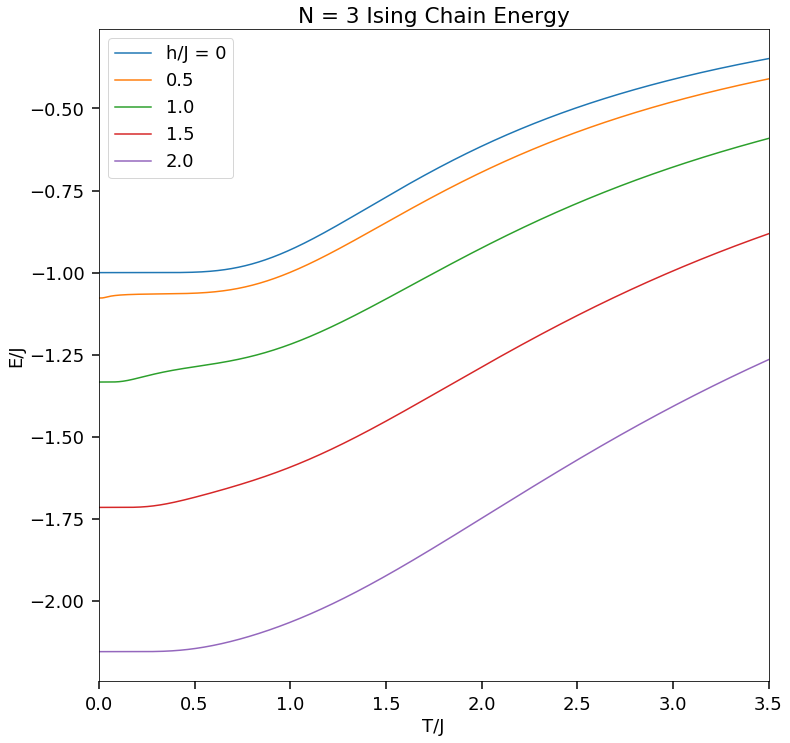

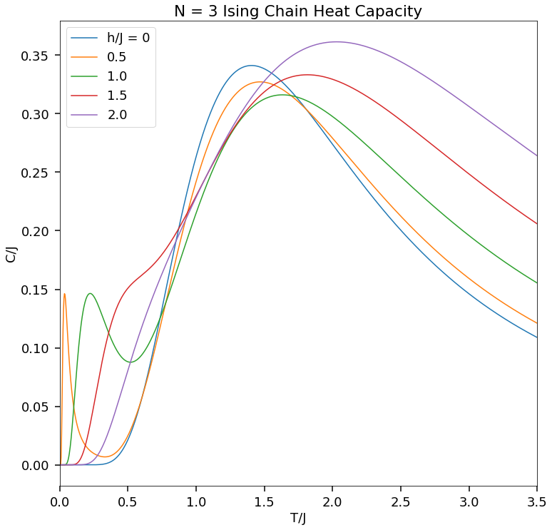

```python
# Plots for N = 3
N = 3
make_plots(N, H_Js, T_Js, titles=['N = {} Ising Chain Energy'.format(N), 'N = {} Ising Chain Heat Capacity'.format(N)])
```

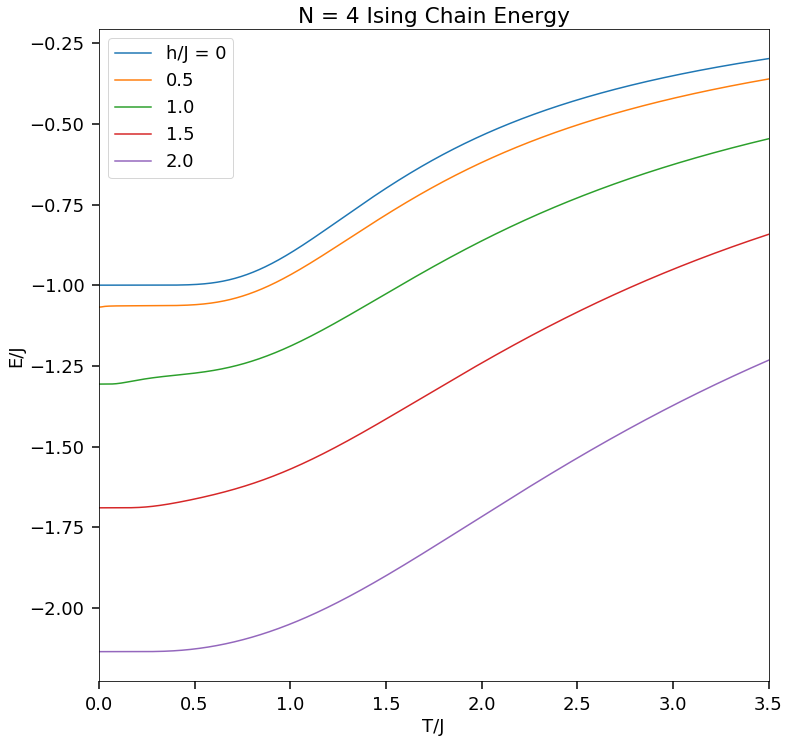

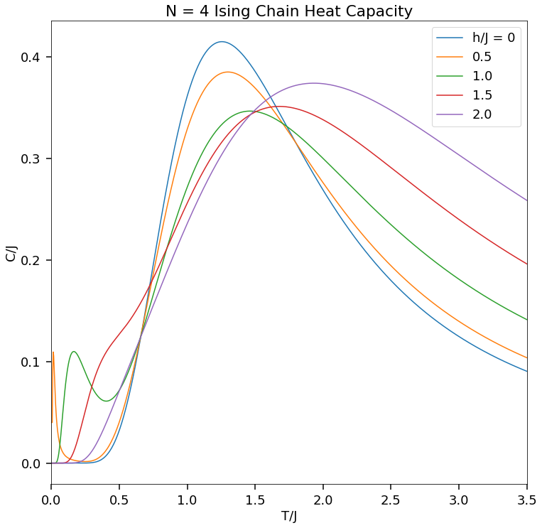

```python
# Plots for N = 4
N = 4
make_plots(N, H_Js, T_Js, titles=['N = {} Ising Chain Energy'.format(N), 'N = {} Ising Chain Heat Capacity'.format(N)])
```

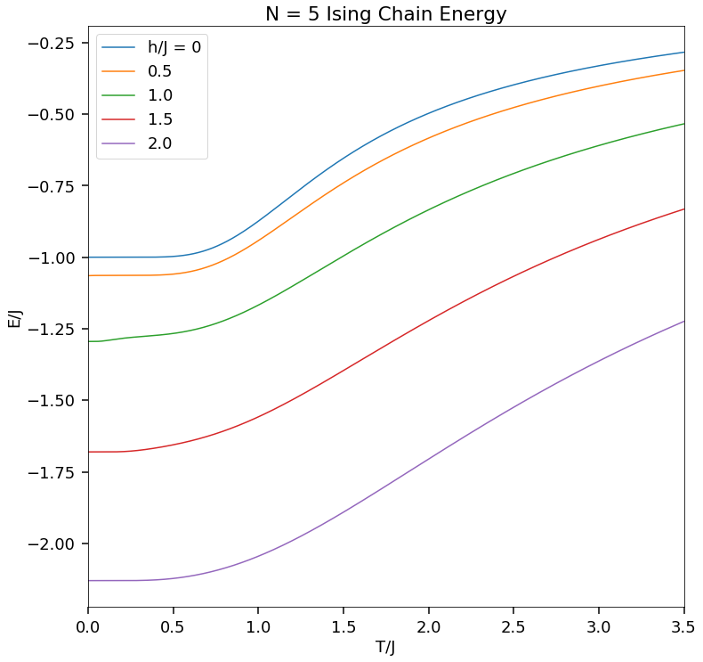

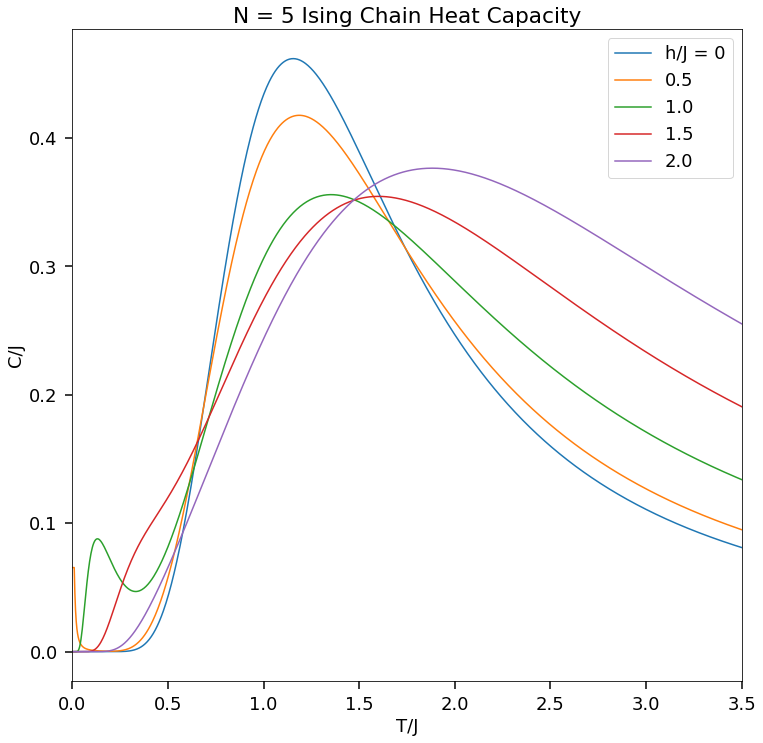

```python
# Plots for N = 5
N = 5
make_plots(N, H_Js, T_Js, titles=['N = {} Ising Chain Energy'.format(N), 'N = {} Ising Chain Heat Capacity'.format(N)])
```

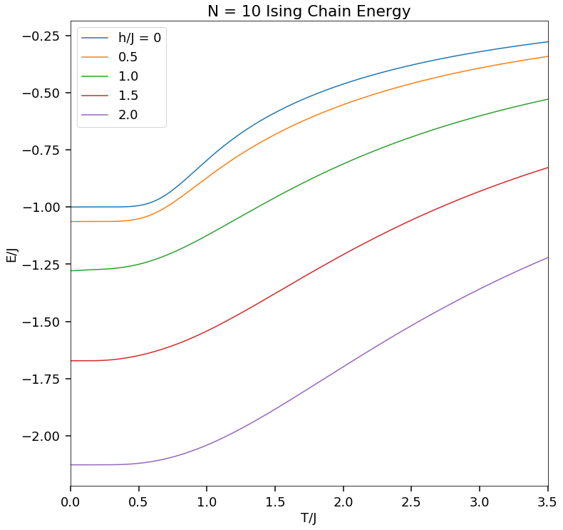

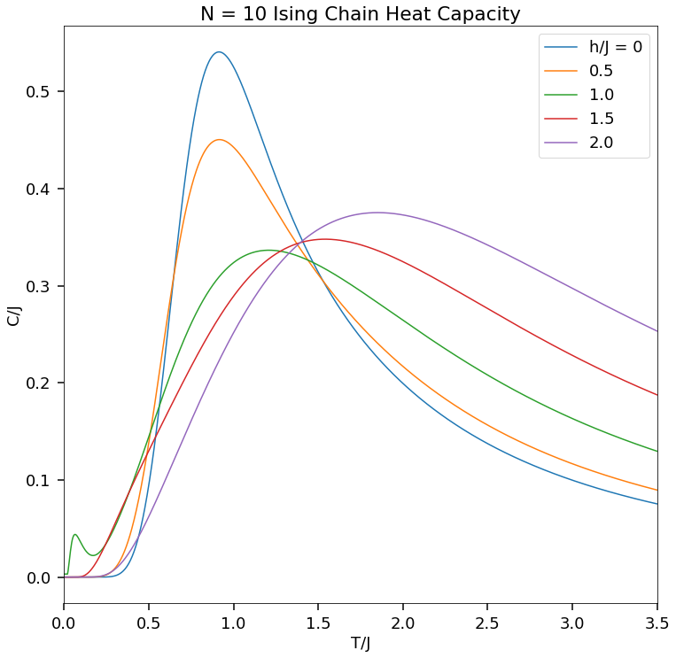

```python
# Plots for N = 10
N = 10
make_plots(N, H_Js, T_Js, titles=['N = {} Ising Chain Energy'.format(N), 'N = {} Ising Chain Heat Capacity'.format(N)])
```